# Github Repository Survival Analysis

Johann Miller, Zack Khan, Eashaan Kumar

## Introduction

Open source projects power the innovations of programmers on a worldwide scale, with companies big and small integrating them into the backbone of their products. However, there is a certain risk with using open source projects, as projects can stop being maintained which leads to bugs being left unfixed and security vulnerabilities unpatched. Also, if you are a programmer who wants to contribute to open source projects, you most likely want to work on a project that will be maintained for a long period of time to ensure your contributions are used by others.

To help potential users of open source projects determine whether they should use/contribute to a specific project, we will be investigating what factors affect the longevity of a github project. Knowing these factors can also help contributors know what to focus on to extend their project’s longevity. Companies like Github that want programmers to continue contributing to open source projects could also use this information as a basis to decide which areas to focus on to increase project longevity as well.

Our initial hypothesis is that the number of unique contributors and number of stars positively correlate with the longevity of a project. We define an abandoned project as a project that has received less than three commits over the last year of our data (2016).

#### Setup python notebook

```python
import pandas as pd
import numpy as np
import matplotlib.pyplot as plt
import seaborn as sns
import datetime
import random
import logging
import requests
import json
from sklearn import preprocessing
from sklearn import decomposition
from sklearn import model_selection
from sklearn import svm
import scipy.stats as stats

logging.basicConfig(level=logging.WARN) # change to DEBUG for extra information
```

## Data Collection

We collected data from the following public sources:

- [Github Archive (on Google BigQuery)](https://bigquery.cloud.google.com/table/githubarchive:year.2016)
- [Github API](https://developer.github.com/v3/)

In order to analyze repositories, we needed several things: features for each repository (number of commits, number of unique contributors), and a label for each repository (the length of time for which it was maintained). In order to collect this information, we compiled data from Github Archive and Github API on public, open-source repositories that have been abandoned. We start this process by getting repositories from Google BigQuery.

If you want to skip to the following steps, we also hosted the resulting csv's: [Event Data](http://github-survival.surge.sh/event.csv), [API Data](http://github-survival.surge.sh/api_data.csv), [Repo Data](http://github-survival.surge.sh/repo_data.csv).

### Get repository events data from BigQuery

*Warning:* *If you process more than 1 TB in one month on BigQuery, you will be charged. These queries total to about 50 GB.*

Github Archive on BigQuery stores event data (pushes, stars, forks, etc.) for every repository from 2011 to the present. In order to do survival analysis, we will select repositories that were created in 2011 and were abandoned in or before 2016. We consider a repository to be abandoned if it receives less than 3 pushes in a year. We also filter out repos that received less than 10 stars in 2011, since we want to analyze somewhat prevalent repositories.

```
-- get all repos starting in 2011
SELECT repo.id, repo.name, repo.url
FROM [githubarchive:year.2011]
WHERE type = 'CreateEvent'
AND JSON_EXTRACT(payload, '$.ref_type') = '"repository"'
-- save table as final.repos_created_in_2011

-- from the previos result, select all repos that received 10 or more stars in 2011
SELECT *
FROM (
  SELECT archive.repo.id AS repo_id, COUNT(*) AS star_count
  FROM [githubarchive:year.2011] AS archive
  INNER JOIN [final.repos_created_in_2011] AS repos
  ON archive.repo.id = repos.repo_id
  WHERE archive.type = "WatchEvent" -- star events
  GROUP BY repo_id
)
WHERE star_count >= 10
-- save table as final.repos_created_in_2011_10_stars

-- select all of the 2011 repos that had 3 or more pushes in 2016
SELECT *
FROM (
  SELECT archive.repo.id AS repo_id, COUNT(*) AS push_count
  FROM [githubarchive:year.2016] AS archive
  INNER JOIN [final.repos_created_in_2011_10_stars] AS repos
  ON archive.repo.id = repos.repo_id
  WHERE archive.type = "PushEvent"
  GROUP BY repo_id
)
WHERE push_count >= 3
-- save table as final.repos_alive_in_2016

-- select all of the 2011 repos that weren't active in 2016
SELECT *
FROM [final.repos_created_in_2011_10_stars]
WHERE repo_id NOT IN (
  SELECT repo_id
  FROM [final.repos_alive_in_2016]
)
-- save table to final.repos_created_in_2011_dead_in_2016

-- for each year 2011-2015, select all events for each repo
SELECT type, repo.name, repo.id, actor.login, created_at
FROM [githubarchive:year.2011]
WHERE repo.id in (
  SELECT repo_id
  FROM [final.repos_created_in_2011_dead_in_2016]
)
SELECT type, repo.name, repo.id, actor.login, created_at
FROM [githubarchive:year.2012]
WHERE repo.id in (
  SELECT repo_id
  FROM [final.repos_created_in_2011_dead_in_2016]
)
SELECT type, repo.name, repo.id, actor.login, created_at
FROM [githubarchive:year.2013]
WHERE repo.id in (
  SELECT repo_id
  FROM [final.repos_created_in_2011_dead_in_2016]
)
SELECT type, repo.name, repo.id, actor.login, created_at
FROM [githubarchive:year.2014]
WHERE repo.id in (
  SELECT repo_id
  FROM [final.repos_created_in_2011_dead_in_2016]
)
SELECT type, repo.name, repo.id, actor.login, created_at
FROM [githubarchive:year.2015]
WHERE repo.id in (
  SELECT repo_id
  FROM [final.repos_created_in_2011_dead_in_2016]
)
-- save tables to final.events-YEAR
```

Once these queries have finished, extract the events tables into a Google Cloud Storage bucket and download them from there.

### Combine all years into one events table

Once all of the events tables are downloaded, we can combine them into a single table.

```python
years = range(2011, 2016)
data_map = {} # hold each year
events = None

for year in years:
    data_map[year] = pd.read_csv('../../data/raw/events-' + str(year) + '.csv') # read in events table for year

# combine events
for year, data in data_map.items():
    if events is not None:
        events = events.append(data)
    else:
        events = data

events.reset_index()
events['created_at'] = pd.to_datetime(events.created_at, infer_datetime_format=True)
events.to_csv('../../data/events.csv', index=False)
events.head()
```

|  | type | repo_name | repo_id | actor_login | created_at |
| --- | --- | --- | --- | --- | --- |
| 0 | PushEvent | clvv/f | 2938132 | clvv | 2011-12-30 22:46:15 |
| 1 | PushEvent | clvv/f | 2938132 | clvv | 2011-12-15 20:41:34 |
| 2 | PushEvent | clvv/f | 2938132 | clvv | 2011-12-11 00:02:38 |
| 3 | PushEvent | btd/gct | 2357050 | btd | 2011-10-15 17:26:33 |
| 4 | IssuesEvent | btd/gct | 2357050 | btd | 2011-09-30 07:30:31 |

### Collect label and features for each repository

Now that we have a table of all the events, we can calculate the labels and features. For each repository we will:

- Find the creation date and the date the project was abandoned.
- Choose an arbitrary split between the two dates. The events occuring before the split will be fed to the model, and everything occuring after it will be ignored. The label will be the number of days from the split until the repository is abandoned.
- We then calculate the features. For each type of event, we calculate:
  - the total number of that event before the split
  - the number of that event in the month before the split
  - the total number of unique users of that event before the split
  - the number of unique users of that event in the month before the split

```python
event_types = set(events.type) # all types of event
activity_event_types = event_types - set(['WatchEvent', 'ForkEvent', 'IssuesEvent']) # maintainence events

# get the label and features for a given repo
def get_repo_data(repo_id):

    # get events for this repo
    e = events[events.repo_id == repo_id]
    e = e.sort_values('created_at')

    # get events that show repo is being maintained
    activity_events = e[e.type.isin(activity_event_types)]

    if len(activity_events) == 0:
        logging.debug('skipping, no events: ' + str(repo_id))
        return None

    # get first and last activity events
    start_date = activity_events.iloc[0].created_at.date()
    end_date = activity_events.iloc[-1].created_at.date() + datetime.timedelta(days=1)
    total_days_alive = (end_date - start_date).days

    if total_days_alive < 2:
        logging.debug('skipping, < 2 days alive: ' + str(repo_id))
        return None

    # select cutoff at random day between start and end
    cutoff_date = start_date + datetime.timedelta(days=random.randrange(1, total_days_alive))
    last_month = cutoff_date - datetime.timedelta(days=30)

    repo_data = {}
    repo_data['repo_id'] = repo_id

    # add label
    repo_data['days_left'] = (end_date - cutoff_date).days

    # add features
    repo_data['days_alive'] = (cutoff_date - start_date).days

    e_prior = e[e.created_at < cutoff_date] # select events before cuttoff
    for event_type in event_types:
        g = e_prior[e_prior.type == event_type] # select events of given type
        repo_data[event_type + '_total'] = len(g)
        repo_data[event_type + '_unique_actors'] = len(g.actor_login.unique())

        g = g[g.created_at > last_month] # select events only in last month
        repo_data[event_type + '_last_month'] = len(g)
        repo_data[event_type + '_last_month_unique_actors'] = len(g.actor_login.unique())

    return repo_data

# all of the features to be collected
feature_cols = ['days_alive'] + [
    x + y for x in event_types for y in ['_total', '_unique_actors', '_last_month', '_last_month_unique_actors']
]
data = pd.DataFrame(columns=(['repo_id', 'days_left'] + feature_cols))

# for each repo, collect data
for repo_id in events.repo_id.unique():
    d = get_repo_data(repo_id)

    if d is not None:
        data.loc[len(data)] = d # add row to data

repo_ids = data.repo_id.unique()
data.to_csv('../../data/repo_data.csv', index=False)
data.head()
```

|  | repo_id | days_left | days_alive | ReleaseEvent_total | ReleaseEvent_unique_actors | ReleaseEvent_last_month | ReleaseEvent_last_month_unique_actors | WatchEvent_total | WatchEvent_unique_actors | WatchEvent_last_month | ... | TeamAddEvent_last_month | TeamAddEvent_last_month_unique_actors | CreateEvent_total | CreateEvent_unique_actors | CreateEvent_last_month | CreateEvent_last_month_unique_actors | ForkEvent_total | ForkEvent_unique_actors | ForkEvent_last_month | ForkEvent_last_month_unique_actors |
| --- | --- | --- | --- | --- | --- | --- | --- | --- | --- | --- | --- | --- | --- | --- | --- | --- | --- | --- | --- | --- | --- |
| 0 | 2938132 | 421 | 1059 | 0 | 0 | 0 | 0 | 1113 | 1093 | 54 | ... | 0 | 0 | 29 | 1 | 0 | 0 | 48 | 47 | 6 | 6 |
| 1 | 2357050 | 484 | 48 | 0 | 0 | 0 | 0 | 0 | 0 | 0 | ... | 0 | 0 | 3 | 1 | 1 | 1 | 0 | 0 | 0 | 0 |
| 2 | 1853708 | 584 | 874 | 0 | 0 | 0 | 0 | 32 | 32 | 1 | ... | 0 | 0 | 2 | 1 | 0 | 0 | 6 | 6 | 1 | 1 |
| 3 | 2285968 | 1096 | 480 | 0 | 0 | 0 | 0 | 181 | 178 | 7 | ... | 0 | 0 | 5 | 1 | 0 | 0 | 20 | 19 | 4 | 3 |
| 4 | 2259211 | 140 | 52 | 0 | 0 | 0 | 0 | 9 | 9 | 0 | ... | 0 | 0 | 5 | 1 | 0 | 0 | 0 | 0 | 0 | 0 |

5 rows × 71 columns

### Get repository info from Github API

```python
api_data = None

for repo_id in repo_ids:
    request_string = 'https://api.github.com/repositories/' + str(repo_id)
    user = json.load(open('../../config.json'))
    resp = requests.get(request_string, auth=(user['github_user'], user['github_pw']))

    s = pd.Series(resp.json())
    if api_data is None:
        api_data = pd.DataFrame(columns=s.keys())

    api_data.loc[len(api_data)] = s

api_data.to_csv('../../data/api_data.csv', index=False)
api_data.head()
```

|  | archive_url | archived | assignees_url | blobs_url | branches_url | clone_url | collaborators_url | comments_url | commits_url | compare_url | ... | subscribers_url | subscription_url | svn_url | tags_url | teams_url | trees_url | updated_at | url | watchers | watchers_count |
| --- | --- | --- | --- | --- | --- | --- | --- | --- | --- | --- | --- | --- | --- | --- | --- | --- | --- | --- | --- | --- | --- |
| 0 | https://api.github.com/repos/clvv/fasd/{archiv... | False | https://api.github.com/repos/clvv/fasd/assigne... | https://api.github.com/repos/clvv/fasd/git/blo... | https://api.github.com/repos/clvv/fasd/branche... | https://github.com/clvv/fasd.git | https://api.github.com/repos/clvv/fasd/collabo... | https://api.github.com/repos/clvv/fasd/comment... | https://api.github.com/repos/clvv/fasd/commits... | https://api.github.com/repos/clvv/fasd/compare... | ... | https://api.github.com/repos/clvv/fasd/subscri... | https://api.github.com/repos/clvv/fasd/subscri... | https://github.com/clvv/fasd | https://api.github.com/repos/clvv/fasd/tags | https://api.github.com/repos/clvv/fasd/teams | https://api.github.com/repos/clvv/fasd/git/tre... | 2017-12-15T11:56:19Z | https://api.github.com/repos/clvv/fasd | 3406 | 3406 |
| 1 | https://api.github.com/repos/btd/luna/{archive... | False | https://api.github.com/repos/btd/luna/assignee... | https://api.github.com/repos/btd/luna/git/blob... | https://api.github.com/repos/btd/luna/branches... | https://github.com/btd/luna.git | https://api.github.com/repos/btd/luna/collabor... | https://api.github.com/repos/btd/luna/comments... | https://api.github.com/repos/btd/luna/commits{... | https://api.github.com/repos/btd/luna/compare/... | ... | https://api.github.com/repos/btd/luna/subscribers | https://api.github.com/repos/btd/luna/subscrip... | https://github.com/btd/luna | https://api.github.com/repos/btd/luna/tags | https://api.github.com/repos/btd/luna/teams | https://api.github.com/repos/btd/luna/git/tree... | 2017-03-30T17:06:01Z | https://api.github.com/repos/btd/luna | 43 | 43 |
| 2 | https://api.github.com/repos/ariya/X2/{archive... | False | https://api.github.com/repos/ariya/X2/assignee... | https://api.github.com/repos/ariya/X2/git/blob... | https://api.github.com/repos/ariya/X2/branches... | https://github.com/ariya/X2.git | https://api.github.com/repos/ariya/X2/collabor... | https://api.github.com/repos/ariya/X2/comments... | https://api.github.com/repos/ariya/X2/commits{... | https://api.github.com/repos/ariya/X2/compare/... | ... | https://api.github.com/repos/ariya/X2/subscribers | https://api.github.com/repos/ariya/X2/subscrip... | https://github.com/ariya/X2 | https://api.github.com/repos/ariya/X2/tags | https://api.github.com/repos/ariya/X2/teams | https://api.github.com/repos/ariya/X2/git/tree... | 2017-02-22T17:52:22Z | https://api.github.com/repos/ariya/X2 | 57 | 57 |
| 3 | https://api.github.com/repos/mixu/nwm/{archive... | False | https://api.github.com/repos/mixu/nwm/assignee... | https://api.github.com/repos/mixu/nwm/git/blob... | https://api.github.com/repos/mixu/nwm/branches... | https://github.com/mixu/nwm.git | https://api.github.com/repos/mixu/nwm/collabor... | https://api.github.com/repos/mixu/nwm/comments... | https://api.github.com/repos/mixu/nwm/commits{... | https://api.github.com/repos/mixu/nwm/compare/... | ... | https://api.github.com/repos/mixu/nwm/subscribers | https://api.github.com/repos/mixu/nwm/subscrip... | https://github.com/mixu/nwm | https://api.github.com/repos/mixu/nwm/tags | https://api.github.com/repos/mixu/nwm/teams | https://api.github.com/repos/mixu/nwm/git/tree... | 2017-12-15T17:26:34Z | https://api.github.com/repos/mixu/nwm | 706 | 706 |
| 4 | https://api.github.com/repos/wadey/ko/{archive... | False | https://api.github.com/repos/wadey/ko/assignee... | https://api.github.com/repos/wadey/ko/git/blob... | https://api.github.com/repos/wadey/ko/branches... | https://github.com/wadey/ko.git | https://api.github.com/repos/wadey/ko/collabor... | https://api.github.com/repos/wadey/ko/comments... | https://api.github.com/repos/wadey/ko/commits{... | https://api.github.com/repos/wadey/ko/compare/... | ... | https://api.github.com/repos/wadey/ko/subscribers | https://api.github.com/repos/wadey/ko/subscrip... | https://github.com/wadey/ko | https://api.github.com/repos/wadey/ko/tags | https://api.github.com/repos/wadey/ko/teams | https://api.github.com/repos/wadey/ko/git/tree... | 2017-05-31T08:00:28Z | https://api.github.com/repos/wadey/ko | 13 | 13 |

5 rows × 74 columns

## Data Exploration

```python
features = data[data.columns[2:]]
label = data['days_left']

features.shape
```

```
(3569, 69)
```

We have 3569 repositories and 69 features. Let's look at the distribution of our data.

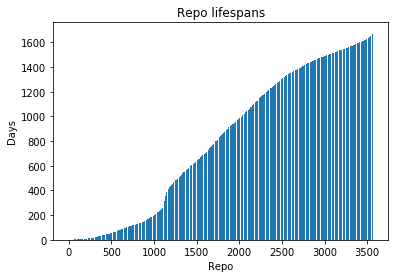

```python
plt.bar(range(0, len(data)), (data.days_left + data.days_alive).sort_values())
plt.title('Repo lifespans')
plt.xlabel('Repo')
plt.ylabel('Days')
plt.show()
```

We have a wide range of lifespans, from repositories that weren't updated beyond the first day to repositories that recieved updates for over 4 years. We can also look closer at the data: for each repository, we can see the events that took place over time.

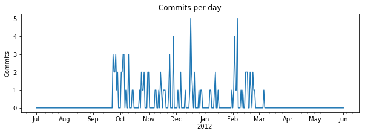

```python
idx = pd.date_range('07-01-2011', '06-01-2012')
repo_id = data.loc[1].repo_id
fig = plt.figure()
e = events[(events.repo_id == repo_id) & (events.type == 'PushEvent')]
g = e.groupby(e.created_at.dt.date).size()
g.index = pd.DatetimeIndex(g.index)
g = g.reindex(idx, fill_value=0)
fig.set_size_inches(10, 3)
plt.title('Commits per day')
plt.ylabel('Commits')
g.plot()
plt.show()
```

As a sanity check, we looked at the number of commits in a random repository. The plot shows the behavior that we expect: commits continue for a couple months after the repository is started, then fall off is the project is abandoned. We can also look at other event types. Here, we will plot the number of commits (PushEvent), the number of stars (WatchEvent), and forks (ForkEvent).

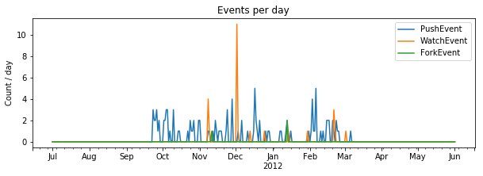

```python
idx = pd.date_range('07-01-2011', '06-01-2012')
repo_id = data.loc[1].repo_id
fig = plt.figure()
for e_type in ['PushEvent', 'WatchEvent', 'ForkEvent']:
    e = events[(events.repo_id == repo_id) & (events.type == e_type)]
    g = e.groupby(e.created_at.dt.date).size()
    g.index = pd.DatetimeIndex(g.index)
    g = g.reindex(idx, fill_value=0)
    fig.set_size_inches(10, 3)
    plt.title('Events per day')
    plt.ylabel('Count / day')
    g.plot(label=e_type)
plt.legend(loc='upper right')
plt.show()
```

Along with the commits, stars and forks fall off after a couple months.

### Correlation Matrix

In order to understand the relationships between our features, we can look for correlations between them.

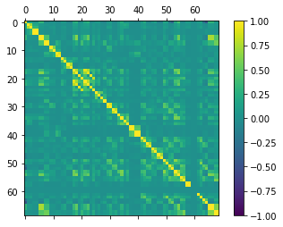

```
Average absolute feature correlation: 0.0953376401834
```

```python
# get correlation matrix
features_scale = pd.DataFrame(preprocessing.scale(features))
correlations = features_scale.corr().fillna(0)

# plot matrix
fig = plt.figure()
ax = fig.add_subplot(111)
cax = ax.matshow(correlations, vmin=-1, vmax=1)
fig.colorbar(cax)
plt.show()

# print average correlation
c = correlations.unstack()
c = (c[c.index.get_level_values(0) > c.index.get_level_values(1)]).sort_values() # select above diagonal
print('Average absolute feature correlation:', c.abs().mean(), '\n')
```

Looking at the matrix, we see that most features have no relation to eachother but a couple have strong correlations. We can look at the pairs of features with the highest correlations.

```python
col1,col2 = c.index.get_level_values(0), c.index.get_level_values(1)
print('Highest correlations:')
for i in range(len(c) - 3, len(c)):
        print((feature_cols[col1[i]], feature_cols[col2[i]]), c.iloc[i])
print('\nInverse correlations:')
for i in range(0, 3):
    print((feature_cols[col1[i]], feature_cols[col2[i]]), c.iloc[i])
c = c.abs().sort_values()
col1,col2 = c.index.get_level_values(0), c.index.get_level_values(1)
print('\nLowest correlations:')
for i in range(0, 3):
    print((feature_cols[col1[i]], feature_cols[col2[i]]), c.iloc[i])
```

```
Highest correlations:
('WatchEvent_unique_actors', 'WatchEvent_total') 0.999950516063
('ReleaseEvent_last_month_unique_actors', 'ReleaseEvent_last_month') 1.0
('PublicEvent_last_month_unique_actors', 'PublicEvent_last_month') 1.0

Inverse correlations:
('CreateEvent_last_month_unique_actors', 'days_alive') -0.431914726678
('PushEvent_last_month_unique_actors', 'days_alive') -0.319013188727
('CreateEvent_last_month', 'days_alive') -0.20875246803

Lowest correlations:
('CreateEvent_last_month', 'TeamAddEvent_last_month_unique_actors') 0.0
('TeamAddEvent_last_month_unique_actors', 'DeleteEvent_last_month_unique_actors') 0.0
('TeamAddEvent_last_month', 'ForkApplyEvent_last_month_unique_actors') 0.0
```

These correlations reveal that we have some redundant features in our repositories. 'WatchEvent' are stars. Since each user can only star repositories once, it makes sense that the number of stars correlates with the number of unique users who starred. Similarily, the Public and Release events are typically done at most once per month. Hence, the values range from 0 to 1 together.

CreateEvent_last_month is inversely correlated with days alive because if the repo is under 30 days old then it has one creation event in the last month. If it is older than 30 days, it will have zero. The inverse correlation betweeen days alive and push events tells us that as a repo ages, the number of people commiting on average goes down.

#### Principal component analysis

PCA analysis is a dimension reduction tool that combines features with a minimal loss of information. Here, we can visualize our complex feature space in only 2 dimensions.

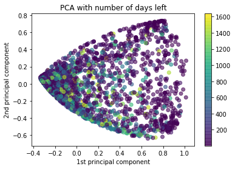

```python
# Create a regular PCA model
pca = decomposition.PCA(n_components=2)

# Fit and transform the data to the model
reduced_data_pca = pca.fit_transform(preprocessing.normalize(features)) # normalize features

plt.scatter(x=reduced_data_pca[:,0], y=reduced_data_pca[:,1], c=label, alpha=0.6)
plt.xlabel('1st principal component')
plt.ylabel('2nd principal component')
plt.colorbar()
plt.title("PCA with number of days left")
plt.show()
```

Optimally, the PCA would show near-homogeneous clusters of data. Instead, we have a single cluster that is a mix of repository lifespans. Based on this plot, we can predict it will be difficult to draw a correlation between these features and repository lifespans.

[More information on PCA](https://klevas.mif.vu.lt/~tomukas/Knygos/principal_components.pdf)

#### SVM

Although the PCA analysis isn't promising, we can try to fit a support vector machine to the data. For classification, SVM selects hyperplanes that minimize error by maximizing the margin between classes of data. For regression, it works similarilty: a hyper plane is fit along the data. If the data is not linear, a kernel function is used to transform the data. Our lifespan label is continuous, so we will use regression.

```
r^2: -0.04 (+/- 0.22)
```

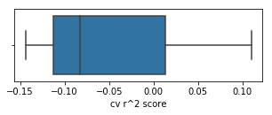

```python
scaled_features = preprocessing.normalize(features) # scale features
parameters ={ # set range for hyperparameters
    'C': np.power(10.0,range(-1,3)), 'epsilon': np.power(10.0,range(-4,-1)), 'kernel': ('poly', 'rbf')
}

svr = svm.SVR()
rgr = model_selection.GridSearchCV(svr, parameters, cv=3) # use gridsearch to select hyperparams
scores = model_selection.cross_val_score(rgr, scaled_features, label, cv=3, n_jobs=-1) # score using cross validation
print("r^2: %0.2f (+/- %0.2f)" % (scores.mean(), scores.std() * 2))
fig = plt.figure()
sns.boxplot(x=scores)
plt.xlabel('cv r^2 score')
fig.set_size_inches(5,1.5)
```

This model did not fit the data. The r^2 value tells us that the variance in life span of the repositories is not at all explained by these features. Since these features are not successful, we can consider other aspects of the data.

## Analysis of programming language vs. lifespan of repository

We thought it would be interesting to see how the programming languages of a project affects its lifespan. The top 5 languages (based on occurences) were Javascript, Ruby, PHP, Python, and Objective C. We created a swarmplot below to analyze the relationship.

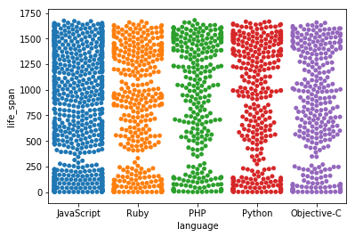

```python
repo_features_df = pd.read_csv('../../data/repo_data.csv', header = 0)
repo_api = pd.read_csv('../../data/api_data.csv', header = 0)
merged_df = pd.merge(repo_features_df , repo_api, left_on = 'repo_id', right_on = 'id')

#Get the top 5 languages used
top_languages = merged_df.groupby('language').size().nlargest(n=5)
#Combine values to get the total lifespan
merged_df['life_span'] = merged_df.days_left + merged_df.days_alive
m = merged_df[merged_df.language.isin(top_languages.keys())]
#Create a swarmplot comparing life_span to programming language
s = sns.swarmplot(x=m.language, y=m.life_span)
plt.show()
```

Every dot in the Swarmplot above is the point that a repository becomes abandoned according to our definition. When the dots align in a wider form, this means there is a higher quantity of data points at that time in the life span. At the one year mark, repositories appear less likely to be abandoned. There doesn't seem to be a huge variation between the languages.

```python
anova_samples = {}
for language, group in m.groupby('language'):
    anova_samples[language] = preprocessing.scale(list(group.life_span))
stats.f_oneway(*anova_samples.values())
```

```
F_onewayResult(statistic=2.7495551400288387e-31, pvalue=1.0)
```

Unfortunately, an anova test shows that the lifespans of different languages are not likely to be from different populations. Another factor that could impact repositories is the sharing license they operate under.

## Analysis of Repository Licenses

All repositories have their own licenses. We hypothesize that different licenses might affect user behaviour is different ways, and hence affect the lifespan of the repository. Popular licenses, such as the MIT license, provide more freedom for the users and hence may extend the lifespan of the repository. So, let's look at the lifespan of each each repository and its corresponding license.

```python
api_data = pd.read_csv('../../data/api_data.csv')
repo_data = pd.read_csv('../../data/repo_data.csv')
```

This data frame will store each repository's license and lifespan. It will be used later for plotting the distributions of each type of licenses>

```python
license_lifespan_df = pd.DataFrame(columns={'license','lifespan'})
```

This data frame consists of consists of repository ids and their corresponding lifespans.

```python
repo_lifespan = pd.DataFrame({'repo_id':repo_data['repo_id'],'lifespan':(repo_data.days_left + repo_data.days_alive)})
```

Next, we have to fetch the licence type for each repository. If we navigate to https://developer.github.com/v3/repos/#get and search the page for "license", we see that license is provided in this format:

```
file.json
"license": {
    "key": "mit",
    "name": "MIT License",
    "spdx_id": "MIT",
    "url": "https://api.github.com/licenses/mit",
    "html_url": "http://choosealicense.com/licenses/mit/"
  }
```

Because DataFrames don't handle multi-dimensional input, this will be returned to us as a string. Using `split(",")`, we can separete the block into 5 components. We can access "spdx_id": "MIT" at index = 2. Then, we can use `split(":")` to access "MIT" at index=1.

```python
# Splits complicated string and searches for 'spdx_id' in second spot
def licenseid_from_license(license):
    license_components = license_block.split(",")
    return license_components[2].split(":")[1]
```

Let's group our data by licence type and obtain the license_id using the funciton above. Next, we will get the list of repository ids from the current group and convert them to integers. We are doing this convertion so that we can search for the lifespan using the repo_id as the key.

Then, for every repository in the group find its lifespan in repo_lifespan dataset. We now have the license type and lifespan of the current repository. We can append this information to license_lifespan_df.

```python
# Group by license
for license_block, group in api_data.groupby(['license']):
    # Get data stored in license block:
    license_id = licenseid_from_license(license_block)
    # Get list of repo_ids that belong to this license_id
    repo_ids = list(group['id'])
    # Convert ids into proper format
    repo_ids = list(map(int, repo_ids))
    # For every repo_id that has this license, get the lifespan and add to dataset
    for repo_id in repo_ids:
        # Obtain lifespan of repo_id
        lifespan = repo_lifespan.loc[repo_lifespan['repo_id'] == repo_id]['lifespan']
        lifespan = list(lifespan)[0]
        # Append license and lifespan dataset
        license_lifespan_df = license_lifespan_df.append({'license':license_id, 'lifespan':lifespan},ignore_index=True)
```

Here is what a sample of the licence_lifespan dataset looks like:

```python
license_lifespan_df.head()
```

|  | lifespan | license |
| --- | --- | --- |
| 0 | 564 | 'AGPL-3.0' |
| 1 | 527 | 'AGPL-3.0' |
| 2 | 1173 | 'AGPL-3.0' |
| 3 | 1611 | 'AGPL-3.0' |
| 4 | 1669 | 'AGPL-3.0' |

We will select the top 5 most popular license types and compare their lifespan distributions. This can be achieved by making a striplot of each license type.

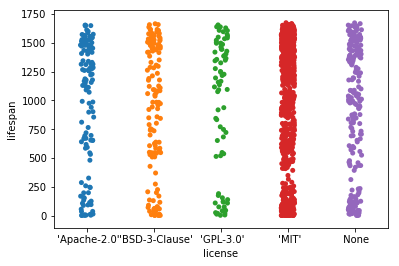

```python
# Obtain top 5 licenses
top_licenses = license_lifespan_df.groupby('license').size().nlargest(n=5)
# Search for all repositories that have one of these licenses
m = license_lifespan_df[license_lifespan_df.license.isin(top_licenses.keys())]
# Create the strip plot
s = sns.stripplot(x=m.license, y=m.lifespan, jitter=True)
plt.show()
```

To get a better understanding, we can perform an ANOVA Test to compare the distribution of each license type. Here is how an ANOVA test is conducted:

Let $\mu_1$ = [true mean lifespan of license type 1]

Let $\mu_2$ = [true mean lifespan of license type 2]

...

Let $\mu_n$ = [true mean lifespan of license type n]

Null Hypothesis: All means are equal

Alternative Hypothesis: Atleast two means are different

$\alpha$ = 0.05

```python
# Map that holds licenses and their lifespan sample data
anova_samples = {}
# Create a map of every license type to its sample of lifespans
for license, group in license_lifespan_df.groupby('license'):
    # Standardize the lifespan samples
    anova_samples[license] = preprocessing.scale(list(group['lifespan']))
# Perform the One way ANOVA test
stats.f_oneway(*anova_samples.values())
```

```
F_onewayResult(statistic=7.7375719907032723e-32, pvalue=1.0)
```

The test-statistic is very small, causing a p-value of 1.0. Because p-value > $\alpha$, we cannot reject the Null Hypothesis, i.e. data suggests that all means of license types are equal. This shows that the licences did not change the distributions of the lifetimes.

## Conclusion

We set out to examine how various features affect the lifespan of repositories. After performing various analysis on our data, it is obvious that our data does not predict lifespans on repositories. We are very surprised with these results; we expected that features like the number of commits and unique number of contributors would be valuable indicators for how long a repository will be maintained. Even programming language and license type, which we thought would certainly have some relation with the success of a project, showed to have no significant impact on the lifespan of repositories when put through anova testing.

Since repository survival is an instance of human behavior, we did not expect to be able to model it perfectly. There are many aspects on the human side of this problem that we are blind to with this model. Other factors determining repository survival, like the popularity of certain tech, the friendliness of the collaboration environment, and others could potentially be added as features to the model and lead to improvement. Still, it comes as a surprise that the basic events that make up all of the activity in a repository do not provide valuable information.

It is worth considering that the poor quality of our model may be due to a fault in the way we set up this expiriment. We have identified some potential sources of error: due to the range of the data, we only were able to consider activity between 2011 and 2016. Repositories still being maintained at the end date of our data were removed from the data set. This meant we missed many of the most popular projects, since we could not label them with a lifespan. Secondly, many of the repositories we did consider were not prominent projects. Our requirement of 10 stars in one year was met by many repositories that weren't pushed to beyond the first few days. As can be seen in the PCA plot, these short-lifespan repositories have a seemingly random alotment of features and led to confusion for the model.

We also considered two elements that we thought would certainly impact the maintenence of repositories: programming language and software license. However, ANOVA tests showed both to have abysmal significance for any difference between the populations. It is possible that the aforementioned data collection lead to failed results in these experiments as well.

All in all, these results are very surprising and as such, deserve to be tested more thouroughly being accepted. As future work, we would suggest that any interested party try different sets of features and test different parameters for data collection.